# Introduction

### RNN Model 6 - Simple LSTM with Selu activation

```python
initializer = tf.keras.initializers.LecunNormal()
model2_6 = tf.keras.models.Sequential([
        tf.keras.layers.LSTM(30, return_sequences=False, input_shape=(168,31),
                             activation='selu',kernel_initializer=initializer),
        tf.keras.layers.Dense(1)
    ])
model2_6.compile(loss="mean_squared_error", optimizer="sgd")

history2_6 = model2_6.fit(rnn_X_train2, rnn_y_train2, epochs=10,
                          validation_data = (rnn_X_val2, rnn_y_val2),verbose=False)
```

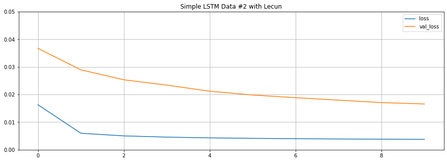

```python
history_plot(history2_6,0.05,'Simple LSTM Data #2 with Lecun')
```

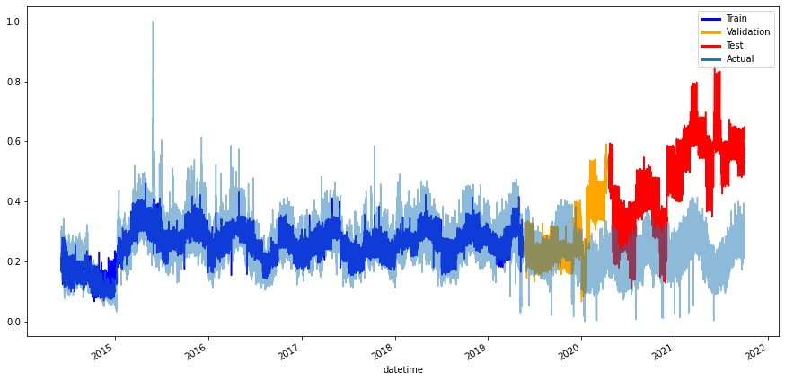

```python
graph_results(to_graph_dfrnn2(model2_6))
```

```python
print_last_loss(history2_6,'Simple LSTM Data #2')
```

```
Simple LSTM Data #2
Loss: 0.003747360548004508
Validation Loss: 0.016568737104535103
```

This model performed much worse on test set despite having better variation in its predictions. Consequently, I will continue using the default activation function next with stacked LSTM model initially using 0.5 dropout.

### RNN Model 7 - Stacked LSTM with 0.5 Dropout

This time I'm doubling the number of neurons in the second layer, inspired by Chollet's GRU code in page 218. I will add both recurrent and normal dropout of 0.5.

```python
model2_7 = tf.keras.models.Sequential([
        tf.keras.layers.LSTM(30, return_sequences=True, input_shape=(168,31),dropout=0.5,recurrent_dropout=0.5),
        tf.keras.layers.LSTM(60, return_sequences=False, dropout=0.5, recurrent_dropout=0.5,),
        tf.keras.layers.Dense(1)
    ])
model2_7.compile(loss="mean_squared_error", optimizer="sgd")

history2_7 = model2_7.fit(rnn_X_train2, rnn_y_train2, epochs=10,
                          validation_data = (rnn_X_val2, rnn_y_val2),verbose=False)
```

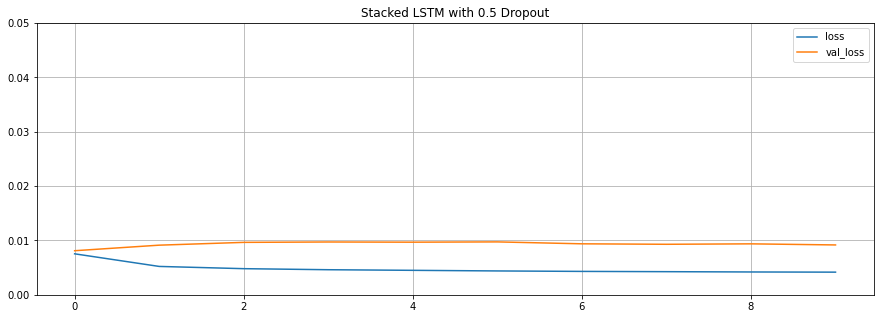

```python
history_plot(history2_7,0.05,'Stacked LSTM with 0.5 Dropout')
```

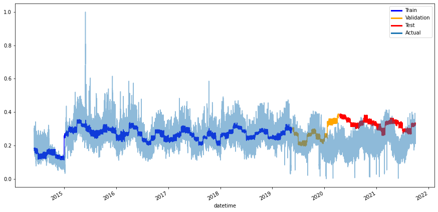

```python
graph_results(to_graph_dfrnn2(model2_7))
```

```python
print_last_loss(history2_7,'Stacked LSTM with 0.5 Dropout')
```

```
Stacked LSTM with 0.5 Dropout
Loss: 0.004166736733168364
Validation Loss: 0.009171692654490471
```

### RNN Model 8 - Simple LSTM with 0.5 Dropout and Gradient Clipping

```python
optimizer = tf.keras.optimizers.SGD(clipnorm=0.5)
model2_8 = tf.keras.models.Sequential([
        tf.keras.layers.LSTM(30, return_sequences=False, input_shape=(168,31),dropout=0.5,recurrent_dropout=0.5),
        tf.keras.layers.Dense(1)
    ])
model2_8.compile(loss="mean_squared_error", optimizer=optimizer)

history2_8 = model2_8.fit(rnn_X_train2, rnn_y_train2, epochs=10,
                          validation_data = (rnn_X_val2, rnn_y_val2),verbose=False)
```

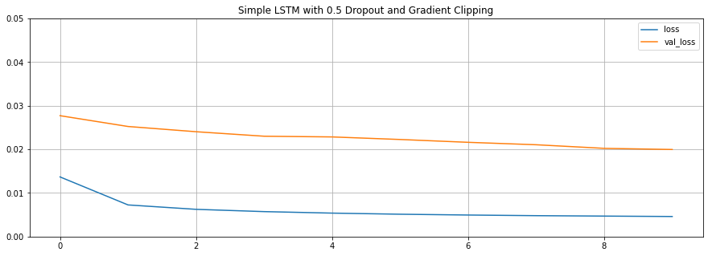

```python
history_plot(history2_8,0.05,'Simple LSTM with 0.5 Dropout and Gradient Clipping')
```

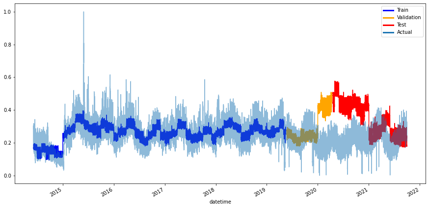

```python
graph_results(to_graph_dfrnn2(model2_8))
```

```python
print_last_loss(history2_8,'Simple LSTM with 0.5 Dropout and Gradient Clipping')
```

```
Simple LSTM with 0.5 Dropout and Gradient Clipping
Loss: 0.004602428991347551
Validation Loss: 0.01996472477912903
```

The results are much worse given the additions to any of the RNN models lead to significantly less performance - due to lower significantly lower accuracy of predicting testing data and overall lower variance of prediction thus signalling lack of generalizability and predictive capacity and loss of the last epoch. This lower performance compared to DNN could be due to my not using early stopping, however, I've used 10 epochs because the RNN models take so long, and DNN models mostly tended to stall off after 10 epochs as well so early stopping likely isn't the main issue - so RNN's computation requirement also makes these models unfavorable when choosing the final model.

Thus, given the RNN models continously underperform and take hours to run, I don't see any reason to continue experimenting with these models and will accept defeat :).

# Best Model

```python
# example of calculate the root mean squared error
from sklearn.metrics import mean_squared_error
def test_mse_calc(model):
    test_predict = pd.DataFrame(model.predict(X_test))
    test_predict.index = X_test.index
    modeldata = test_predict.merge(y_test,left_index=True,right_index=True).rename({0:'predicted_y'},axis=1)
    errors = mean_squared_error(modeldata['$/MWh'], modeldata['predicted_y'], squared=False)
    return errors
```

```python
MSE_DNN = []
MSE_DNN.append(test_mse_calc(model1_1))
MSE_DNN.append(test_mse_calc(model1_2))
MSE_DNN.append(test_mse_calc(model1_3))
MSE_DNN.append(test_mse_calc(model1_4))
MSE_DNN.append(test_mse_calc(model1_5))
MSE_DNN.append(test_mse_calc(model1_6))
MSE_DNN.append(test_mse_calc(model1_7))
```

```python
pd.DataFrame(MSE_DNN).set_index(pd.DataFrame(['Model 1', 'Model 2','Model 3',
                                              'Model 4','Model 5','Model 6','Model 7'])[0]).rename({0:'MSE'},axis=1)
```

| 0 | MSE |
| --- | --- |
| Model 1 | 0.294403 |
| Model 2 | 0.071341 |
| Model 3 | 0.182240 |
| Model 4 | 0.052774 |
| Model 5 | 0.050837 |
| Model 6 | 0.049489 |
| Model 7 | 0.063985 |

To decide the best model, I will one by one look at DNN Model 1 and RNN Model 2 to identify the best among the two, then decide the top model from among the two main models. I will identify the top model firstly based on how the loss improves throughout the epochs for both train and validation set, with the goal of the model to decrease the loss of both sets in unison. Next, I will look at the last epoch’s train and validation loss to be lower than others. Finally and most importantly, I will look at the graph of the actual data compared to the predicted data for all sets, but most importantly the test set. For the DNN models only, I will also look at the mean squared error of the test data – I have not done this for RNN models because the models had performed badly on the top three anyway and knowing I wouldn’t have to choose the best from this category in retrospect in conjunction with the kernel crashing thus having to rerun the RNN models which would’ve taken the whole day, I will not look at their performance on test data with regards to the exact mse. So, given the other information of the RNN models were stored before I could calculate mse of test data, I have decided to just look at the first three categories I’ve mentioned.

Looking firstly at DNN, among the 7 models, I believe it’s best to focus on models after model 3 given the significant variation from the actual test value of the predictions.

1. **Model 1_4** is a strong candidate to be the top DNN model: we can see that the validation and training loss decrease in unison which is a great sign of generalizability and the models ability to find the bottom of the gradient to accurately diminish the loss. We can also see that the model has the lowest loss among all four, for both training and validation data, with a slightly higher validation loss for validation. We can also see this reflected in the accuracy graph as the predicted train and validation data is highly intersected with the actual data. However, looking at the testing data’s accuracy on the graph, we can see predicted variables are slightly lower values overall are lower than the actual price data and the mse of the testing data is it second highest among these four models.
2. **Model 1_5**: we can see that this model will likely not be a top model among the four. In the history graph, the training loss keeps decreasing as expected however validation loss seems erratic, signaling a gradient loss problem meaning the loss function is unable to accurately find the bottom of the gradient. We can also see that the train and validation loss are slightly above model 1_4 at ~2.4s, and looking at the accuracy graph, that although the train and validation data lie within the actual data, it seems to have predicted the prices with less variation, likely signaling a more restrictive model than model 1_4. However, this model testing prediction more often than not lies within the range of the actual test set and slightly above. We can see that the test loss is the second best as well which is in line with the graph. Yet, because the validation loss graph showed a gradient descent issue, the loss values for both sets were slightly higher and most importantly the predicted data seemed to be more restricted in its variation, I will remove this model from consideration.
3. **Model 1_6:** we can see that this model will likely be determined to be the top model. The training loss decreases as expected whereas although validation does also decrease, it seems to have the similar problem in model 1_5 of not being able to find the lower end of the gradient as evidenced by the high movement/changes of the loss after each epoch, signally the problem of vanishing or exploding gradients. Looking at the train and validation set losses of the last epoch, we can see that it’s worse than model 1_4 but better than model 1_5. For all of the models, the trend has been for validation to be slightly higher than training, indicating similar levels of generalizability to new data. Looking at the accuracy graph however, we can see that it seems to have predicted testing data better than model 1_4 and model1_5: the predicted testing data has more variation than model1_5 while having the ability to stay more within the ranges of the actual data compared to model1_4. This can also be seen from the mse of the test set given this model has the lowest test set mean squared error.
4. **Model 1_7**: we can see that this model performed well however worse than model1_6. It has a similar graph of a decreasing loss for both train and validation tests across the epochs, signally a lack of a gradient problem which is a good sign. Its validation loss is also lower than train loss which is a first among these four models, with both losses being on the lower end. However, this model seems to be the worst when we look at the predicted vs actual graph: the predicted values overall have less variance thus the model is more restrictive which is understandable given the difference between model 1_6 and this one is lower learning rate which likely caused these restrictive results. However most importantly, we can see that the test predictions lie much beyond the limits on the actual data and this model has the highest mse for the test set, thus this model is unfortunately the worst among the 4 solely because it was unable to perform as well as it did for train and validation set to test set.

To highlight, less variation in predicted data than the actual data is undesirable even if the data falls within the range of the actual data given the project is on energy pricing data which has low range of the outcome variables as it stands, thus it’s important for the model to identify this variation well.

Looking next at RNN, among the 8 models, I will give a briefer analysis of the results given all of them performed worse than most if not all of the DNN models.

Among the RNN models, the best one seems to be model 2_5 - although it performed more or less similarly to 2_3 (same LSTM model, different dataset), it computed it much quicker.

Given none of the RNN models performed well on predicting testing data both with regards to the variation of the predictions and the ability to fall within the range of test data in combination with high loss values for both train and validation sets and their requiring much more computation resources, I will choose the best model among the DNN models.

Among the DNN models, the best model is 1_6 given it has the lowest test mean squared error in combination with well performing historical loss values for train and validation sets and variation of the predicted values for all sets.

## Works Cited

Jesus Lago, Grzegorz Marcjasz, Bart De Schutter, Rafał Weron, Forecasting day-ahead electricity prices: A review of state-of-the-art algorithms, best practices and an open-access benchmark, Applied Energy, Volume 293, 2021, 116983, ISSN 0306-2619, https://doi.org/10.1016/j.apenergy.2021.116983.

A. Jędrzejewski, J. Lago, G. Marcjasz and R. Weron, "Electricity Price Forecasting: The Dawn of Machine Learning," in IEEE Power and Energy Magazine, vol. 20, no. 3, pp. 24-31, May-June 2022, doi: 10.1109/MPE.2022.3150809.

Francois Chollet. Deep Learning with Python. Manning Publications, Greenwich, CT, first edition, 2017

Aurelien Geron. Hands-On Machine Learning with Scikit-Learn and TensorFlow. O’Reilly Media, Boston, MA, first edition, 2017